# Module-8

# HOMEWORK PROBLEM 2

**I have used cowplot package in this assignment. It may balk if the package is not installed.**

Using different .Rmd file than you used for Problem 1 pushing both the Markdown and knitted .html file to the same “homework-week-4” repository, do the following:

Load in the dataset “zombies.csv” from my GitHub repo at https://github.com/difiore/ADA2016. This data includes the first and last name and gender of the entire population of 1000 people who have survived the zombie apocalypse and are now ekeing out an existence somewhere on the East Coast, along with several other variables (height, weight, age, number of years of education, number of zombies they have killed, and college major see here for info on major

#### [1]Calculate the population mean and standard deviation for each quantitative random variable (height, weight, age, number of zombies killed, and years of education). NOTE: You will not want to use the built in var() and sd() commands as these are for samples.

```r
#File selection
zombieData <- read.csv("zombies.csv", sep = ",", header = TRUE, stringsAsFactors = FALSE)
#Defining generic mean and standard deviation functions
mean_pop <- function(ranVar){return (sum(zombieData[ranVar])/nrow(zombieData))}
sd_pop <- function(ranVar){return (sqrt(sum((zombieData[ranVar] - mean_pop(ranVar))^2)/nrow(zombieData)))}
#Height
mean_height <- mean_pop("height")
sd_height <- sd_pop("height")
#Weight
mean_weight <- mean_pop("weight")
sd_weight <- sd_pop("weight")
#Age
mean_age <- mean_pop("age")
sd_age <- sd_pop("age")
#Number of Zombies Killed
mean_zombies_killed<- mean_pop("zombies_killed")
sd_zombies_killed <- sd_pop("zombies_killed")
#Years of Education
mean_years_of_education <- mean_pop("years_of_education")
sd_years_of_education <- sd_pop("years_of_education")
pop_stats <- data.frame(STAT = c("MEAN","SD"), HEIGHT = c(mean_height,sd_height), WEIGHT = c(mean_weight,sd_weight), AGE = c(mean_age,sd_age), Z_KILL = c(mean_zombies_killed,sd_zombies_killed), Y_ED = c(mean_years_of_education,sd_years_of_education))
#Results
pop_stats
```

```
##   STAT   HEIGHT    WEIGHT       AGE   Z_KILL     Y_ED
## 1 MEAN 67.63010 143.90748 20.046961 2.992000 2.996000
## 2   SD  4.30797  18.39186  2.963583 1.747551 1.675704
```

#### [2]Use ggplot and make boxplots of each of these variable by gender.

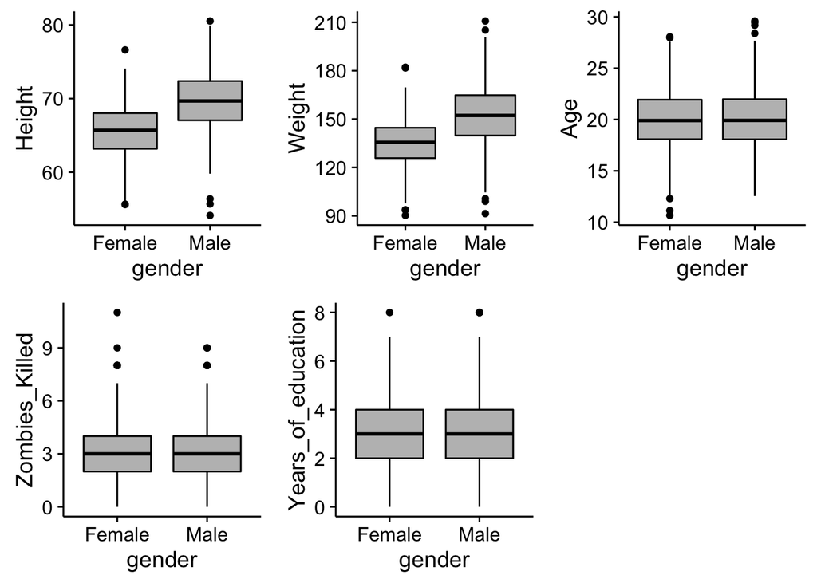

```r
attach(zombieData)
require(ggplot2)
require(cowplot)
plot_a<-ggplot(zombieData,aes(gender,height)) + geom_boxplot(color = "black",fill = "grey", shape = 1 ) + ylab("Height")
plot_b<-ggplot(zombieData,aes(gender,weight)) + geom_boxplot(color = "black",fill = "grey") + ylab("Weight")
plot_c<-ggplot(zombieData,aes(gender,age)) + geom_boxplot(color = "black",fill = "grey") + ylab("Age")
plot_d<-ggplot(zombieData,aes(gender,zombies_killed)) + geom_boxplot(color = "black",fill = "grey") + ylab("Zombies_Killed")
plot_e<-ggplot(zombieData,aes(gender,years_of_education)) + geom_boxplot(color = "black",fill = "grey") + ylab("Years_of_education")
plot_grid(plot_a,plot_b,plot_c,plot_d,plot_e, align = 'h')
```

#### [3]Use ggplot and make a scatterplots of height and weight in relation to age. Do these variables seem to be related? In what way?

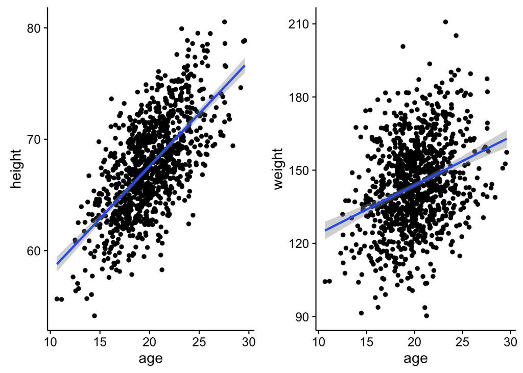

```r
sca_plot_a<-ggplot(zombieData, aes(x = age, y = height)) + geom_point() + geom_smooth(method = "lm")
sca_plot_b<-ggplot(zombieData, aes(x = age,  y = weight)) + geom_point() + geom_smooth(method = "lm")
plot_grid(sca_plot_a,sca_plot_b,align = 'h')
```

**The plots signify an increase in height and weight with age. But the increase in height is much more than that of weight as the age increases.**

#### [4] Using histograms and Q-Q plots, check whether the quantitative variables seem to be drawn from a normal distribution. Which seem to be and which do not (hint: not all are drawn from the normal distribution)? For those that are not, can you determine what common distribution they are drawn from?

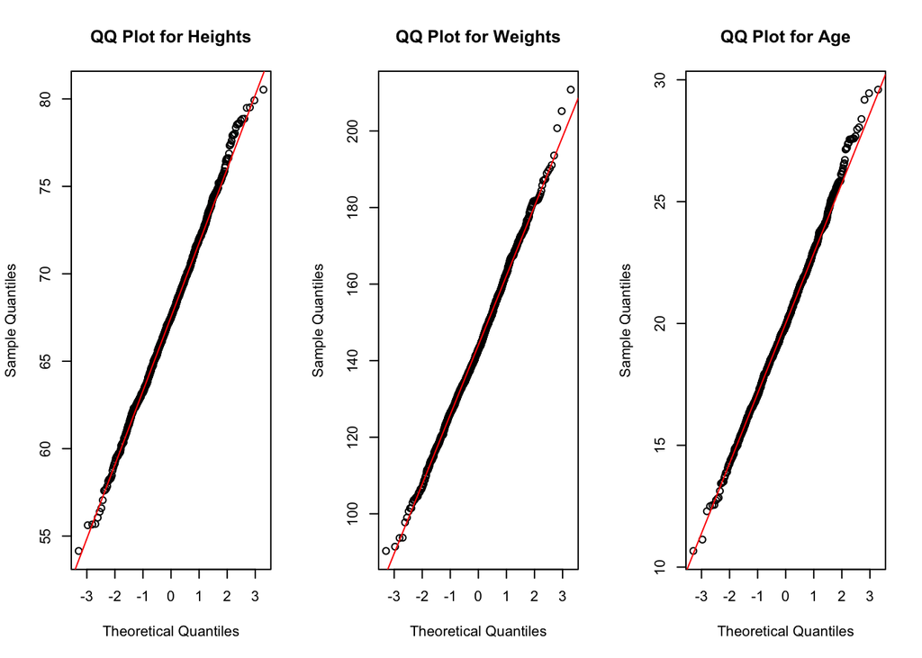

```r
#Q-Q Plots
par(mfrow = c(1, 3))
#Height
qqnorm(height, main = "QQ Plot for Heights"); qqline(height, col = "red")
#Weight
qqnorm(weight, main = "QQ Plot for Weights"); qqline(weight, col = "red")
#Age
qqnorm(age, main = "QQ Plot for Age"); qqline(age, col = "red")
```

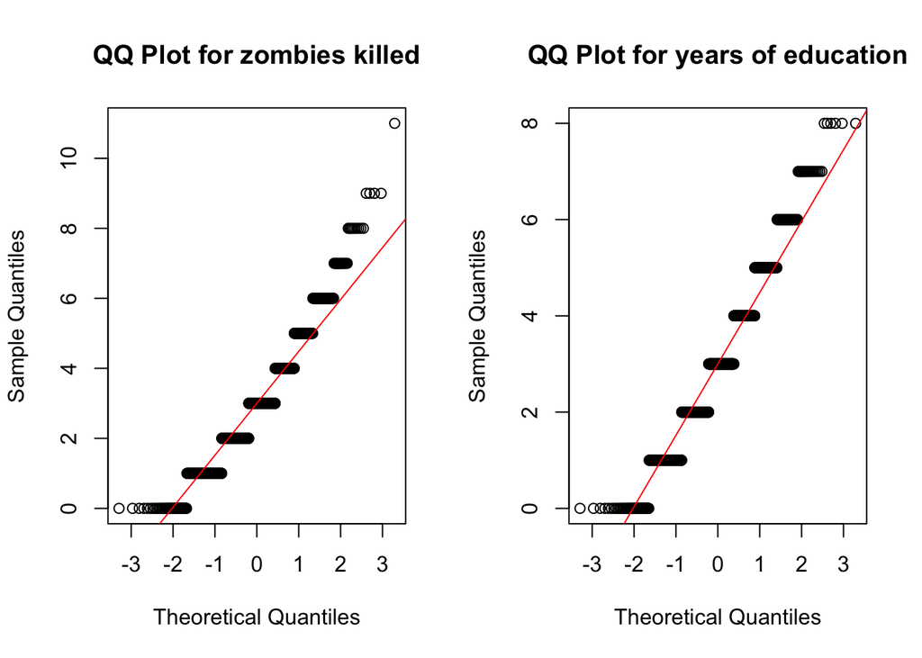

```r
par(mfrow = c(1, 2))
#Zombies_Killed
qqnorm(zombies_killed, main = "QQ Plot for zombies killed"); qqline(zombies_killed, col = "red")
#Years_of_Education
qqnorm(years_of_education, main = "QQ Plot for years of education"); qqline(years_of_education, col = "red")
```

**Height, Weight, and Age come from a normal distribution as the plots signify.** **Plotting histograms from zombies_killed and years_of_education in order to determine their distribution**

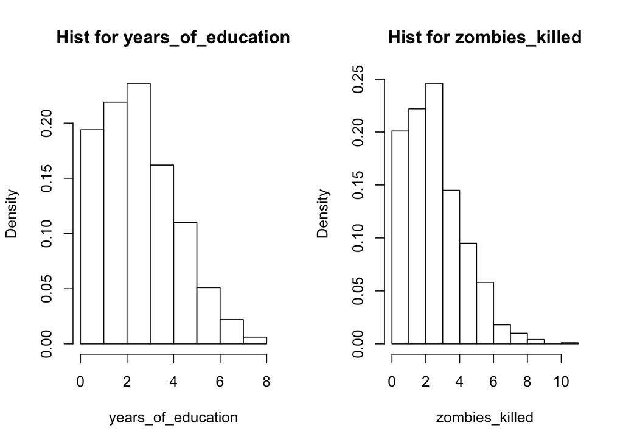

```r
par(mfrow = c(1, 2))
hist(zombieData$years_of_education,freq = FALSE,xlab = "years_of_education",main = "Hist for years_of_education")
hist(zombieData$zombies_killed,freq = FALSE,xlab = "zombies_killed",main = "Hist for zombies_killed")
```

**These seem to belong to poisson distribution.** **If I build a q-q plot for poisson random variables against normal quantiles I get a similar plot as the QQ-plot of zombies_killed and years_of_education.i.e.**

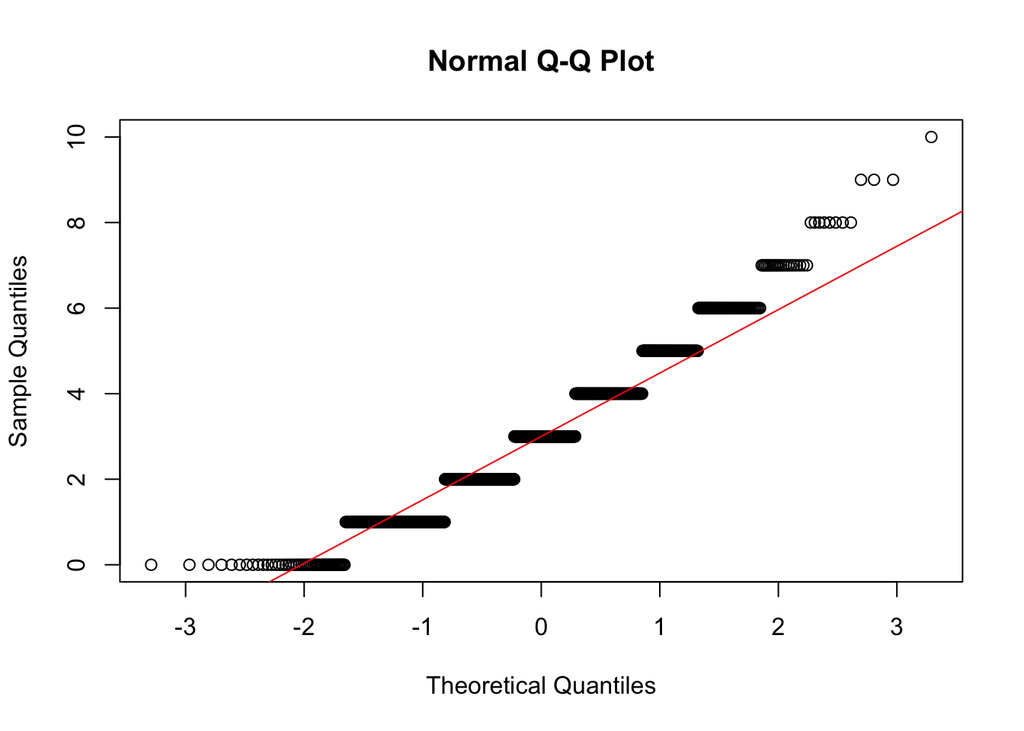

```r
mypois<-rpois(n=1000,lambda = 3) #Assuming lambda =3
qqnorm(mypois); qqline(mypois,col="red")
```

#### [5] Now use the sample() function to sample ONE subset of 30 zombies (without replacement) from this population and calculate the mean and sample standard deviation for each variable. Also estimate the standard error for each variable and construct the 95% confidence interval for each mean. Note that for the variables that are not drawn from the normal distribution, you will need to base your estimate of the CIs on some different distribution.

```r
sample_pop_stat <- NULL #Defining the variable to store sample population stat
# Defining a function to create random samples for various quant variables e.g. height
sample_var <- function(var,n)
{
  return (sample(var, size = n, replace = FALSE))
}
#Defining a function to calculate CI for mean for normal distributions
standard_CI <- function(mean,se)
{
  lower <- mean - qnorm((1 - .05)/2)*se
  upper <- mean + qnorm((1 - .05/2))*se
  return (c(lower,upper))
}
#Defining sample size
sampleSize <- 30
#Generating random samples and computing mean, standard deviation, standard error of the mean, and confidence intervals for all quantitative variables.
#Height
sample_height <- sample_var(height,sampleSize)
mean_sample_height <- round(mean(sample_height),2)
sd_sample_height <- round(sd(sample_height),2)
se_height <- round(sd_sample_height/sqrt(length(sample_height)),2)
ci_height <- standard_CI(mean_sample_height, se_height)

#Weight
sample_weight <- sample_var(weight,sampleSize)
mean_sample_weight <- round(mean(sample_weight),2)
sd_sample_weight <- round(sd(sample_weight),2)
se_weight <- round(sd_sample_weight/sqrt(length(sample_weight)),2)
ci_weight <- standard_CI(mean_sample_weight, se_weight)

#Age
sample_age <- sample_var(age,sampleSize)
mean_sample_age <- round(mean(sample_age),2)
sd_sample_age <- round(sd(sample_age),2)
se_age <- round(sd_sample_age/sqrt(length(sample_age)),2)
ci_age <- standard_CI(mean_sample_age, se_age)

#Zombies Killed
sample_zombies_killed <- sample_var(zombies_killed,sampleSize)
mean_sample_zombies_killed <- round(mean(sample_zombies_killed),2)
sd_sample_zombies_killed <- round(sd(sample_zombies_killed),2)
se_zombies_killed <- round(sd_sample_zombies_killed/sqrt(length(sample_zombies_killed)),2)
#Calculating CI for poisson distribution mean via bootstraping
z<-NULL
for (i in 1:10000){
  z[i] <- mean(sample(sample_zombies_killed,length(sample_zombies_killed),replace = TRUE))
}
ci_zombies_killed <- quantile(z,c(.025,0.95))

#Years of Education
sample_years_of_education <- sample_var(years_of_education,sampleSize)
mean_sample_years_of_education <- round(mean(sample_years_of_education),2)
sd_sample_years_of_education <- round(sd(sample_years_of_education),2)
se_years_of_education<- round(sd_sample_years_of_education/sqrt(length(sample_years_of_education)),2)
#Calculating CI for poisson distribution mean via bootstraping
y<-NULL
for (i in 1:10000){
  y[i] <- mean(sample(sample_years_of_education,length(sample_years_of_education),replace = TRUE))
}
ci_years_of_education <- quantile(y,c(.025,0.95))
#Results
sample_pop_stat <- data.frame(SAM_POP_STAT = c("MEAN","SD","SE","CI"), HEIGHT = c(mean_sample_height, sd_sample_height, se_height, toString(round(ci_height,2))), WEIGHT = c(mean_sample_weight, sd_sample_weight, se_weight, toString(round(ci_weight,2))),AGE = c(mean_sample_age, sd_sample_age, se_age, toString(round(ci_age,2))),Z_KILL = c(mean_sample_zombies_killed, sd_sample_zombies_killed, se_zombies_killed, toString(round(ci_zombies_killed,2))),Y_ED = c(mean_sample_years_of_education, sd_sample_years_of_education, se_years_of_education, toString(round(ci_years_of_education,2))))
sample_pop_stat
```

```
##   SAM_POP_STAT       HEIGHT         WEIGHT          AGE     Z_KILL
## 1         MEAN        68.18          136.6        20.02        3.3
## 2           SD         4.79          16.11         3.34        1.6
## 3           SE         0.87           2.94         0.61       0.29
## 4           CI 68.23, 69.89 136.78, 142.36 20.06, 21.22 2.77, 3.77
##         Y_ED
## 1        2.9
## 2       1.58
## 3       0.29
## 4 2.33, 3.37
```

#### [6] Now drawn 99 more random samples of 30 zombies out and calculate the mean for each of the these samples. Together with the first sample you drew out, you now have a set of 100 means for each variable (each based on 30 observations), which constitutes a sampling distribution for each variable. What are the means and standard deviations of this distribution for each variable? How do the standard deviations compare to the standard errors estimated in [5]? What do these sampling distributions look like? Are they normally distributed? What about for those variables that you concluded were not originally drawn from a normal distribution?

```r
mean_multi_sample_stat<-NULL
mean_multi_sample_height<-NULL
mean_multi_sample_weight<-NULL
mean_multi_sample_age<-NULL
mean_multi_sample_zombies_killed<-NULL
mean_multi_sample_years_of_education<-NULL
for(i in 1:99){
  mean_multi_sample_height[i]<-mean(sample_var(height,sampleSize)) #Mean of random samples of heights
  mean_multi_sample_weight[i]<-mean(sample_var(weight,sampleSize)) #Mean of random samples of weights
  mean_multi_sample_age[i]<-mean(sample_var(age,sampleSize)) #Mean of random samples of age
  mean_multi_sample_zombies_killed[i]<-mean(sample_var(zombies_killed,sampleSize)) #Mean of random samples of zombies killed
  mean_multi_sample_years_of_education[i]<-mean(sample_var(years_of_education,sampleSize)) #Mean of random samples of years of education
}
mean_multi_sample_height[100]<-mean_sample_height
mean_multi_sample_weight[100]<-mean_sample_weight
mean_multi_sample_age[100]<-mean_sample_age
mean_multi_sample_zombies_killed[100]<-mean_sample_zombies_killed
mean_multi_sample_years_of_education[100]<-mean_sample_years_of_education

#Mean and Standard Error of the sampling distributions
#where mean = mean of all possible means of sample size = SampleSize
#and standard deviation of the sampling distribution = standard error
mean_of_mean_ms_height <- mean(mean_multi_sample_height)
sd_of_mean_ms_height <- sd_height/sqrt(sampleSize)

mean_of_mean_ms_weight <- mean(mean_multi_sample_weight)
sd_of_mean_ms_weight <- sd_weight/sqrt(sampleSize)

mean_of_mean_ms_age <- mean(mean_multi_sample_age)
sd_of_mean_ms_age <- sd_age/sqrt(sampleSize)

mean_of_mean_ms_zombies_killed <- mean(mean_multi_sample_zombies_killed)
sd_of_mean_ms_zombies_killed <- sd_zombies_killed/sqrt(sampleSize)

mean_of_mean_ms_years_of_education <- mean(mean_multi_sample_years_of_education)
sd_of_mean_ms_years_of_education <- sd_years_of_education/sqrt(sampleSize)

mean_multi_sample_stat<-data.frame(MULTI_SAM_STAT=c("MEAN","SD/SE"),HEIGHT = c(mean_of_mean_ms_height,sd_of_mean_ms_height),WEIGHT = c(mean_of_mean_ms_weight,sd_of_mean_ms_weight),AGE = c(mean_of_mean_ms_age,sd_of_mean_ms_age),Z_KILL = c(mean_of_mean_ms_zombies_killed,sd_of_mean_ms_zombies_killed),Y_ED = c(mean_of_mean_ms_years_of_education,sd_of_mean_ms_years_of_education))
#Results
mean_multi_sample_stat
```

```
##   MULTI_SAM_STAT     HEIGHT     WEIGHT        AGE    Z_KILL      Y_ED
## 1           MEAN 67.7483513 143.705467 20.0362437 2.9853333 3.0063333
## 2          SD/SE  0.7865241   3.357878  0.5410737 0.3190578 0.3059403
```

```r
#Comparing standard error of the mean in [5] against standard error of the sampling distribution in [6]
comp<-NULL
comp<-data.frame(COMP=c("S.Err.Mean","S.Dev.Sam.Dist./S.Err."), HEIGHT = c(se_height,sd_of_mean_ms_height), WEIGHT = c(se_weight,sd_of_mean_ms_weight), AGE = c(se_age,sd_of_mean_ms_age), Z_KILL = c(se_zombies_killed,sd_of_mean_ms_zombies_killed), Y_ED = c(se_years_of_education,sd_of_mean_ms_years_of_education))
comp
```

```
##                     COMP    HEIGHT   WEIGHT       AGE    Z_KILL      Y_ED
## 1             S.Err.Mean 0.8700000 2.940000 0.6100000 0.2900000 0.2900000
## 2 S.Dev.Sam.Dist./S.Err. 0.7865241 3.357878 0.5410737 0.3190578 0.3059403
```

**Standard error of the mean is not equal to the standard error/standard deviation of the sampling distribution but is close to it and hence can be used as an estimator.**

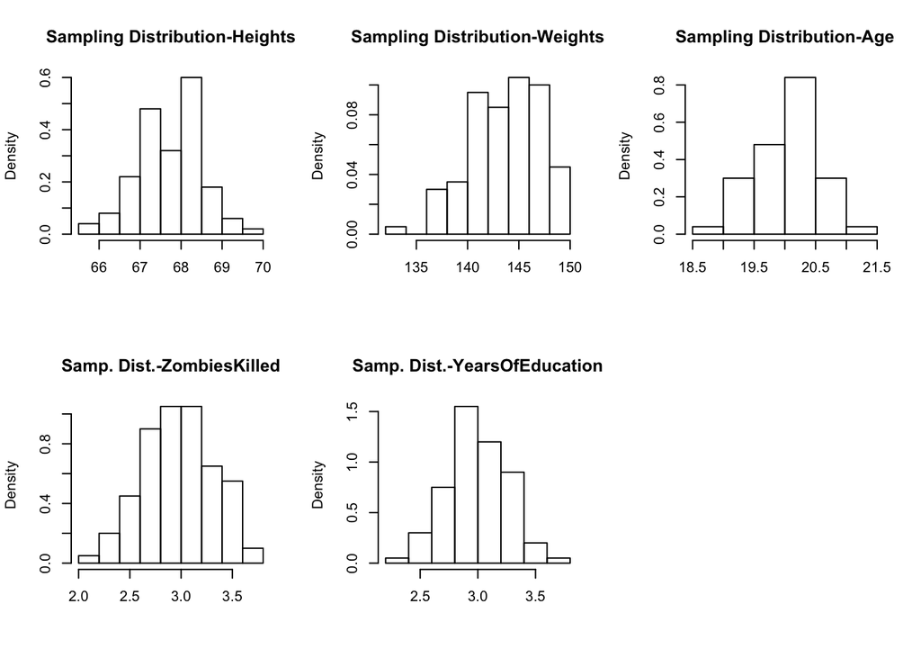

```r
#Plotting the sampling distributions
par(mfrow = c(2,3))
hist(mean_multi_sample_height,freq = FALSE, main = "Sampling Distribution-Heights",xlab = "")
hist(mean_multi_sample_weight,freq = FALSE,main = "Sampling Distribution-Weights",xlab = "")
hist(mean_multi_sample_age,freq = FALSE,main = "Sampling Distribution-Age",xlab = "")
hist(mean_multi_sample_zombies_killed,freq = FALSE,main = "Samp. Dist.-ZombiesKilled",xlab = "")
hist(mean_multi_sample_years_of_education,freq = FALSE,main = "Samp. Dist.-YearsOfEducation",xlab = "")
par(mfrow = c(2, 3))
```

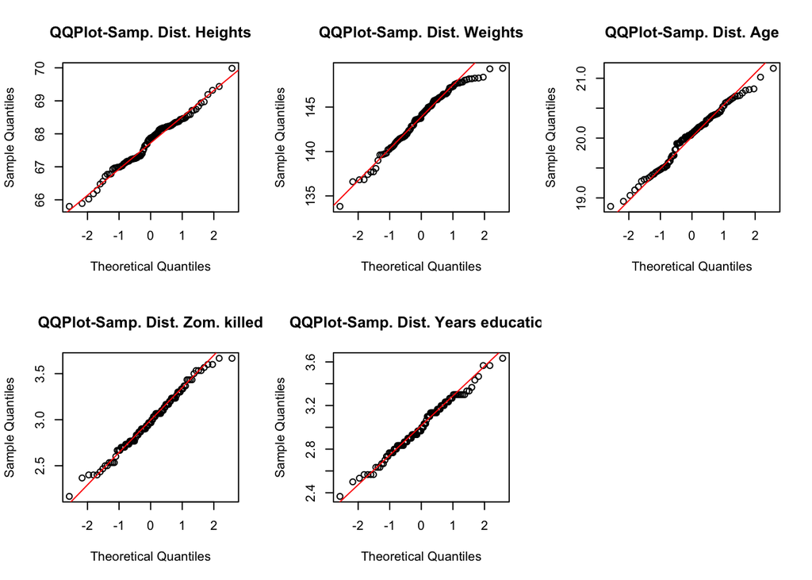

```r
#Are these sampling distributions normally distributed
qqnorm(mean_multi_sample_height, main = "QQPlot-Samp. Dist. Heights"); qqline(mean_multi_sample_height, col="red")
qqnorm(mean_multi_sample_weight, main = "QQPlot-Samp. Dist. Weights"); qqline(mean_multi_sample_weight, col="red")
qqnorm(mean_multi_sample_age, main = "QQPlot-Samp. Dist. Age"); qqline(mean_multi_sample_age, col="red")
qqnorm(mean_multi_sample_zombies_killed, main = "QQPlot-Samp. Dist. Zom. killed"); qqline(mean_multi_sample_zombies_killed, col="red")
qqnorm(mean_multi_sample_years_of_education, main = "QQPlot-Samp. Dist. Years education"); qqline(mean_multi_sample_years_of_education, col="red")
```

**The sampling distributions of all the quantitative variables are normally distributed.This is the practical realisation of “central limit theorum”.**